# Practical Machine Learning: Prediction Assignment

Raju Shah

May 30, 2016

### Introduction

Using devices such as Jawbone Up, Nike FuelBand, and Fitbit it is now possible to collect a large amount of data about personal activity relatively inexpensively. These type of devices are part of the quantified self movement - a group of enthusiasts who take measurements about themselves regularly to improve their health, to find patterns in their behavior, or because they are tech geeks.

### Data

The data sets originated from : Ugulino, W.; Cardador, D.; Vega, K.; Velloso, E.; Milidiu, R.; Fuks, H. Wearable Computing: Accelerometers’ Data Classification of Body Postures and Movements. Proceedings of 21st Brazilian Symposium on Artificial Intelligence. Advances in Artificial Intelligence - SBIA 2012 Read more: http://groupware.les.inf.puc-rio.br/har#ixzz40iHm7JQz

### Goal

For this project, we are given data from accelerometers on the belt, forearm, arm, and dumbell of 6 research study participants. Our training data consists of accelerometer data and a label identifying the quality of the activity the participant was doing. Our testing data consists of accelerometer data without the identifying label. Our goal is to predict the labels for the test set observations. We will also create a report describing how we built our model, how we used cross validation, what we think the expected out of sample error is, and why we made the choices we did. We will also use our prediction model to predict 20 different test cases.

```r
library(ggplot2)
library(caret)
library(randomForest)
library(gbm)
setwd("d:/coursera/datascience/08-practical-machine-learning/assignment")
```

### Load data

```r
# loading data
train_file <- "pml-training.csv"
test_file <- "pml-testing.csv"
train_url <- "https://d396qusza40orc.cloudfront.net/predmachlearn/pml-training.csv"
if (!file.exists(train_file)){
    download.file(train_url,train_file)
}

test_url <- "https://d396qusza40orc.cloudfront.net/predmachlearn/pml-testing.csv"
if (!file.exists(test_file)){
    download.file(test_url,test_file)
}

training <- read.csv(train_file, na.strings = c("NA", "#DIV/0!", ""))
testing  <- read.csv(test_file,  na.strings = c("NA", "#DIV/0!", ""))

# remove near zero covariates
nsv <- nearZeroVar(training, saveMetrics = T)
training <- training[, !nsv$nzv]
# remove variables with more than 80% missing values
nav <- sapply(colnames(training), function(x) if(sum(is.na(training[, x])) > 0.8*nrow(training)){return(T)}else{return(F)})
training <- training[, !nav]
# calculate correlations
cor <- abs(sapply(colnames(training[, -ncol(training)]), function(x) cor(as.numeric(training[, x]), as.numeric(training$classe), method = "spearman")))
```

The training set has **19622** samples and **58** potential predictors after filtering.

There doesn’t seem to be any strong predictors that correlates with `classe` well, so linear regression model is probably not suitable in this case. Boosting and random forests algorithms may generate more robust predictions for our data.

### Boosting model

- Fit model with boosting algorithm and 10-fold cross validation to predict `classe` with all other predictors.
- Plot accuracy of this model on the scale `[0.9, 1]`.

```r
#partition the dataset into train and test set
dataIndex <- createDataPartition(training$classe, p = 0.7, list = FALSE)
training_set <- training[dataIndex,]
testing_set <- training[-dataIndex,]
modelcontrol <- trainControl(method = "cv", number = 10, verboseIter = FALSE)

set.seed(123)
boostFit <- train(classe ~ ., method = "gbm", data = training_set, verbose = FALSE, trControl = modelcontrol)
boostFit
```

```
## Stochastic Gradient Boosting
##
## 13737 samples
##    58 predictor
##     5 classes: 'A', 'B', 'C', 'D', 'E'
##
## No pre-processing
## Resampling: Cross-Validated (10 fold)
## Summary of sample sizes: 12362, 12363, 12363, 12362, 12363, 12364, ...
## Resampling results across tuning parameters:
##
##   interaction.depth  n.trees  Accuracy   Kappa
##   1                   50      0.9997817  0.9997239
##   1                  100      0.9997817  0.9997239
##   1                  150      0.9998545  0.9998160
##   2                   50      0.9997817  0.9997239
##   2                  100      0.9998545  0.9998160
##   2                  150      0.9998545  0.9998160
##   3                   50      0.9997817  0.9997239
##   3                  100      0.9998545  0.9998160
##   3                  150      0.9998545  0.9998160
##
## Tuning parameter 'shrinkage' was held constant at a value of 0.1
##
## Tuning parameter 'n.minobsinnode' was held constant at a value of 10
## Accuracy was used to select the optimal model using  the largest value.
## The final values used for the model were n.trees = 150,
##  interaction.depth = 3, shrinkage = 0.1 and n.minobsinnode = 10.
```

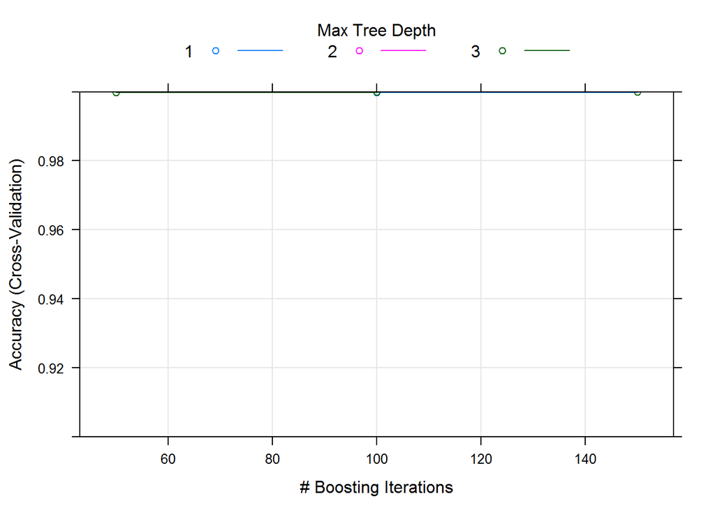

```r
plot(boostFit, ylim = c(0.9, 1))
```

### Random forests model

- Fit model with random forests algorithm and 10-fold cross validation to predict `classe` with all other predictors.
- Plot accuracy of the model on the **same scale** as boosting model.

```r
set.seed(123)
rfFit <- train(classe ~ ., method = "rf", data = training_set, trControl = modelcontrol)
```

```r
rfFit
```

```
## Random Forest
##
## 13737 samples
##    58 predictor
##     5 classes: 'A', 'B', 'C', 'D', 'E'
##
## No pre-processing
## Resampling: Cross-Validated (10 fold)
## Summary of sample sizes: 12362, 12363, 12363, 12362, 12363, 12364, ...
## Resampling results across tuning parameters:
##
##   mtry  Accuracy   Kappa
##    2    0.9950497  0.9937388
##   41    0.9998545  0.9998160
##   80    0.9998545  0.9998160
##
## Accuracy was used to select the optimal model using  the largest value.
## The final value used for the model was mtry = 41.
```

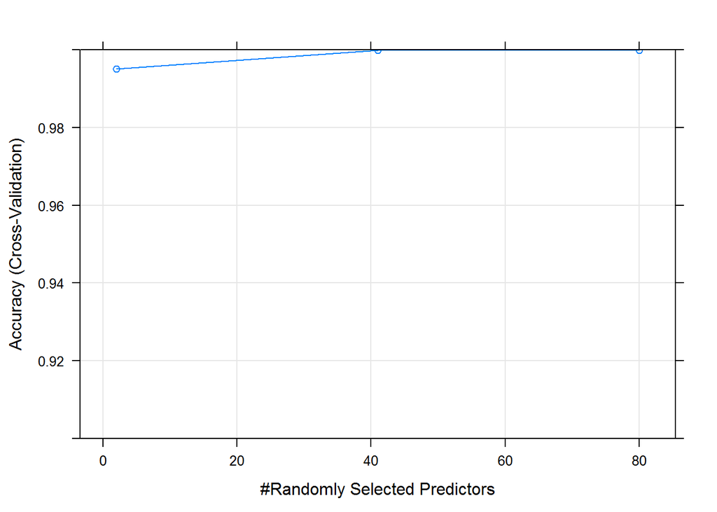

[output not shown]

[output not shown]

```r
plot(rfFit, ylim = c(0.9, 1))
```

```r
## Calculate OOS Error
missClass = function(values, predicted) {
        sum(predicted != values) / length(values)
}
OOS_errRateRF = missClass(testing_set$classe, rfFit_predicted)
OOS_errRateRF
```

```
## [1] 0.0001699235
```

### Final model and prediction

```r
# final model
rfFit$finalModel
```

```
##
## Call:
##  randomForest(x = x, y = y, mtry = param$mtry)
##                Type of random forest: classification
##                      Number of trees: 500
## No. of variables tried at each split: 41
##
##         OOB estimate of  error rate: 0.01%
## Confusion matrix:
##      A    B    C    D    E  class.error
## A 3906    0    0    0    0 0.0000000000
## B    1 2657    0    0    0 0.0003762227
## C    0    0 2396    0    0 0.0000000000
## D    0    0    0 2252    0 0.0000000000
## E    0    0    0    1 2524 0.0003960396
```

```r
# prediction
prediction <- as.character(predict(rfFit, testing))
```

```r
# write prediction files
pml_write_files = function(x){
  n = length(x)
  for(i in 1:n){
    filename = paste0("prediction/problem_id_", i, ".txt")
    write.table(x[i], file = filename, quote = FALSE, row.names = FALSE, col.names = FALSE)
  }
}
pml_write_files(prediction)
```